# Recast coding challenge (Jan)

2023-01-05

Loading datasets + preprocessing.

```r
setwd("/Users/asya/Dropbox/_ jobs/Recast Marketing Data Analyst R Exercises")

library(dplyr)
library(tidyr)

acme_spend <- read.csv("acme_spend.csv") %>%
  mutate(date = as.Date(date, '%m/%d/%y')) # change the string to R data
acme_revenue <- read.csv("acme_revenue.csv") %>%
  mutate(date = as.Date(date, '%m/%d/%y')) # change the string to R data
```

## Part II

Create a wide dataset, where each row has a unique date.

For ‘acme_spend’: each row has observations for a unique date, each column contains spend values for each unique channel.

For ‘acme_revenue’: no permutations needed; each row has observations for a unique date, each column contains revenue values for each unique revenue source.

```r
# spend permutation, make a wide version of the dataset
acme_spend_wide <- acme_spend %>% select(-X) %>%
  pivot_wider(id_cols = date, names_from = channel,
              values_from = spend, names_prefix='channel_', # add a name prefix for readability
              values_fill = NA)

acme_revenue <- acme_revenue %>% select(-X)

# merge datasets
final <- acme_spend_wide %>%
  full_join(., acme_revenue, by = 'date') # gives a union of two sets,
                                          # which is convenient given that
                                          # we don't know which dataset is larger


write.csv(final, "/Users/asya/Dropbox/_ jobs/Recast Marketing Data Analyst R Exercises/Final_Data.csv", row.names=FALSE)
```

## Part I

Instead of regular experessions, I work with the R date object.

**a. Which channel had the most spend in 2022?**

```r
acme_spend %>%
  filter(format(as.Date(date, '%m/%d/%y'), '%Y') == '2022') %>%
  group_by(channel) %>%
  summarise(spend = sum(spend, na.rm=T)) %>% # sum spend for each channel in 2022
  arrange(-spend) # sort from highest to lowest values
```

```
## # A tibble: 10 × 2
##    channel                     spend
##    <chr>                       <dbl>
##  1 online_video             6046009.
##  2 facebook_prospecting     5510542.
##  3 pinterest                4860868.
##  4 linear_tv                3349218.
##  5 google_nonbranded_search 2879264.
##  6 facebook_retargeting     2118334.
##  7 twitter                  1380244.
##  8 tiktok                    631448.
##  9 online_display            336289.
## 10 google_branded_search     151708
```

```r
acme_spend %>%
  filter(format(as.Date(date, '%m/%d/%y'), '%Y') == '2022') %>%
  group_by(channel) %>%
  summarise(spend = sum(spend, na.rm=T)) %>%
  arrange(-spend) %>%
  .[1,1] %>% unlist() # alternatively, we can print the name of the channel only
```

```
##        channel
## "online_video"
```

**b. Which channel had the largest increase in spend so far in 2022 compared to the same date range in 2021?**

```r
acme_spend %>% filter(format(date, '%Y') == '2022') %>% summarise(min = min(date), max = max(date))
```

```
##          min        max
## 1 2022-01-01 2022-10-31
```

```r
# get the last day for 2022 observations
last_day <- acme_spend %>% filter(format(date, '%Y') == '2022') %>% summarise(max = max(date)) %>% .[[1]]


# create a wide dataset
acme_spend_21_22 <- acme_spend %>%
  # subset the orinigal dataset to leave only certain dates
  # the dates for 2021 are in between Jan 1 and the month and the day of 'last_day'
  filter((date >= '2021-01-01' & date <= paste('2021', format(last_day, '%m'), format(last_day, '%d'), sep='-')) |
           (date >= '2022-01-01' & date <= last_day)) %>% # and the dates for 2022 are in between Jan 1 and last_day
  mutate(year = format(date, '%Y')) %>% # add a year var to group by it
  group_by(year, channel) %>%
  summarise(spend = sum(spend, na.rm=T)) %>% # sum spend for each channel within each year
  # create a wide dataframe, so it's easier to calculate the 2021-22 difference
  pivot_wider(id_cols = channel,
              names_from = year,
              names_prefix = 'spend_',
              values_from = spend) %>%
  mutate(difference = spend_2022 - spend_2021) %>%
  arrange(-difference) # sort from highest to lowest difference
acme_spend_21_22
```

```
## # A tibble: 10 × 4
##    channel                  spend_2021 spend_2022 difference
##    <chr>                         <dbl>      <dbl>      <dbl>
##  1 online_video               2737624.   6046009.   3308384.
##  2 facebook_prospecting       5345138.   5510542.    165405.
##  3 google_nonbranded_search   2776069.   2879264.    103195.
##  4 linear_tv                  3260718.   3349218.     88500.
##  5 facebook_retargeting       2073586.   2118334.     44749.
##  6 twitter                    1339613.   1380244.     40631.
##  7 online_display              327030.    336289.      9259.
##  8 tiktok                      622373.    631448.      9076.
##  9 google_branded_search       150409     151708       1299
## 10 pinterest                  5654592.   4860868.   -793724.
```

```r
acme_spend_21_22[1,'channel']
```

```
## # A tibble: 1 × 1
##   channel
##   <chr>
## 1 online_video
```

**c. Did Acme spend more with Google or Facebook in 2022? How has this changed since 2021?**

```r
library(stringr) # connected with tidyr, another way to deal w reg exps
library(ggplot2)

acme_spend_21_22_gfb <- acme_spend_21_22 %>%
  # create a new column that specifies whether the channel is fb or google
  mutate(source = str_extract(channel, '^facebook|^google')) %>%
  filter(!is.na(source)) %>% # drop columns that aren't fb or google
  group_by(source) %>%
  summarise_at(vars(starts_with('spend_')), ~sum(.x))

acme_spend_21_22_gfb
```

```
## # A tibble: 2 × 3
##   source   spend_2021 spend_2022
##   <chr>         <dbl>      <dbl>
## 1 facebook   7418723.   7628877.
## 2 google     2926478.   3030972.
```

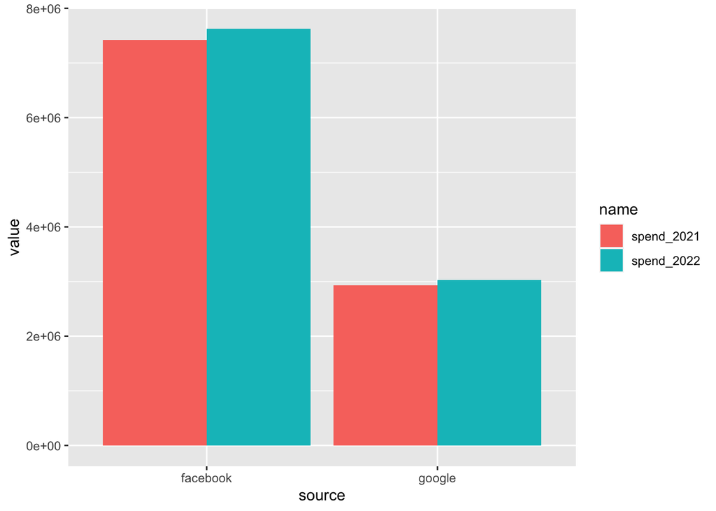

```r
acme_spend_21_22_gfb %>%
  pivot_longer(cols=starts_with('spend_')) %>%
  ggplot(aes(x = source, y = value, fill = name)) +
  geom_bar(stat = "identity", position = position_dodge())
```

**d. Which retailer (DTC, Amazon or Walmart) accounted for the most revenue in October 2022?**

```r
acme_revenue %>%
  filter(format(date, '%m-%Y') == '10-2022') %>%
  # sum the values in all columns that start w 'revenue_'
  summarise_at(vars(starts_with('revenue_')), ~sum(.x, na.rm=T)) %>%
  pivot_longer(cols = everything()) %>%
  mutate(name = gsub('revenue_', '', name)) %>%  #print nice names
  arrange(-value) # sort in descending order
```

```
## # A tibble: 3 × 2
##   name       value
##   <chr>      <dbl>
## 1 amazon  5989397.
## 2 walmart 4085565.
## 3 dtc     1916607.
```

```r
# or just print the name
acme_revenue %>%
  filter(format(date, '%m-%Y') == '10-2022') %>%
  summarise_at(vars(starts_with('revenue_')), ~sum(.x, na.rm=T)) %>%
  which.max() %>% names()
```

```
## [1] "revenue_amazon"
```

**e. In terms of total revenue, are there any anomalous days?**

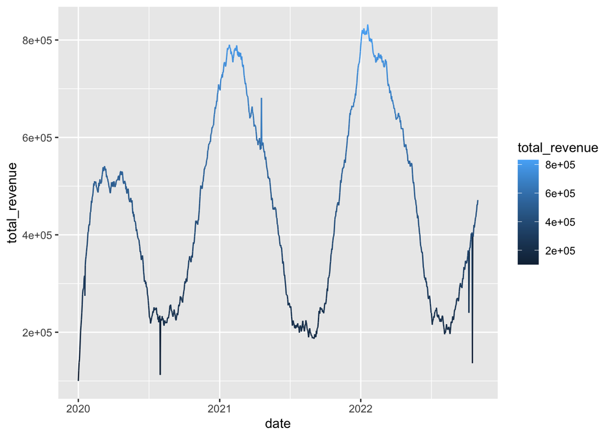

```r
acme_revenue_total <- acme_revenue %>%
  mutate(total_revenue = rowSums(.[2:4], na.rm = TRUE)) # calculate total revenue

# keep only total revenues and dates
acme_revenue_total <- acme_revenue_total[, c("date", "total_revenue")]

# visualize time series
ggplot(acme_revenue_total,
       aes(x = date, y = total_revenue, color=total_revenue)) + geom_line()
```

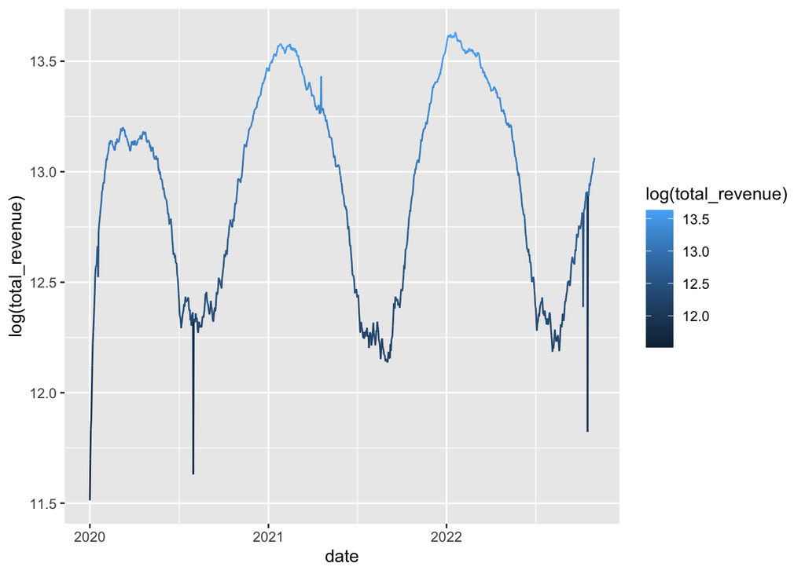

```r
# we can also compress the data range by taking a log
# to see the patterns and outliers more clearly:
ggplot(acme_revenue_total,
       aes(x = date, y = log(total_revenue),
           color=log(total_revenue))) + geom_line()
```

**f. In which month of the year does Acme tend make the most revenue?**

```r
# first, create month and year variables
library(lubridate)
```

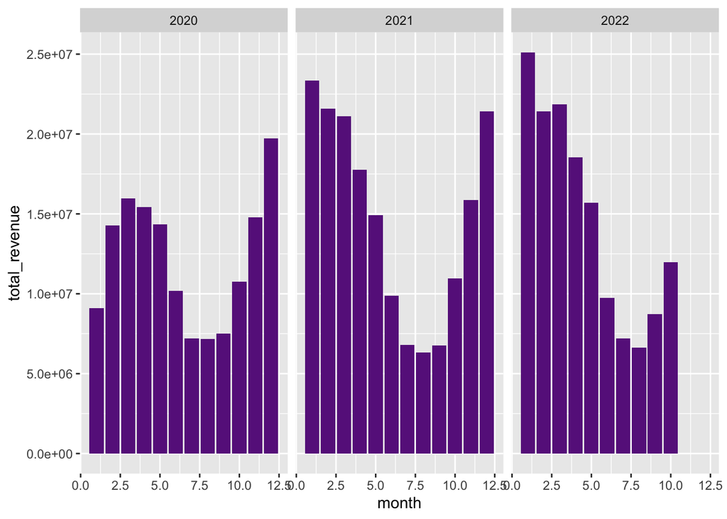

```r
acme_revenue_total <- acme_revenue_total %>%
  mutate(month = month(date),
         year = year(date))

ggplot(acme_revenue_total, aes(x = month, y = total_revenue)) +
      geom_bar(stat = "identity", fill = "darkorchid4") +
  facet_wrap(~ year)
```

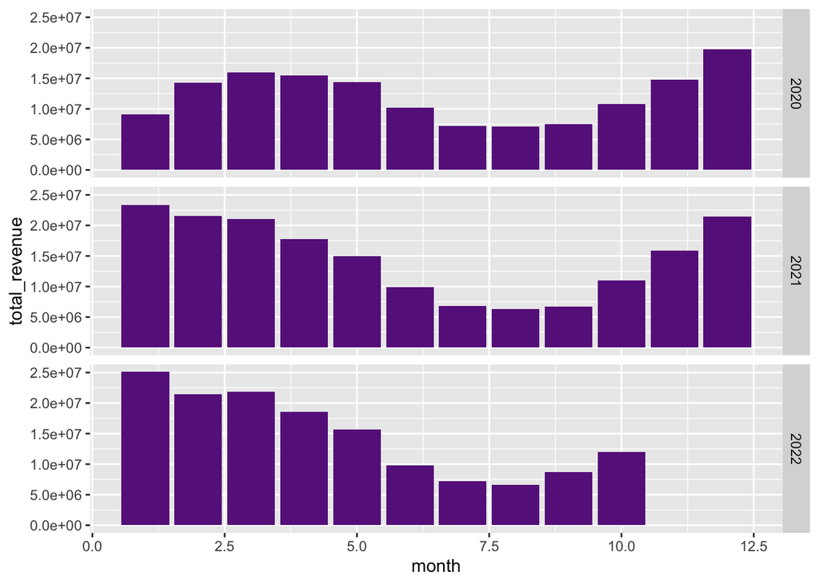

```r
ggplot(acme_revenue_total, aes(x = month, y = total_revenue)) +
      geom_bar(stat = "identity", fill = "darkorchid4") +
  facet_grid(year ~ .)
```

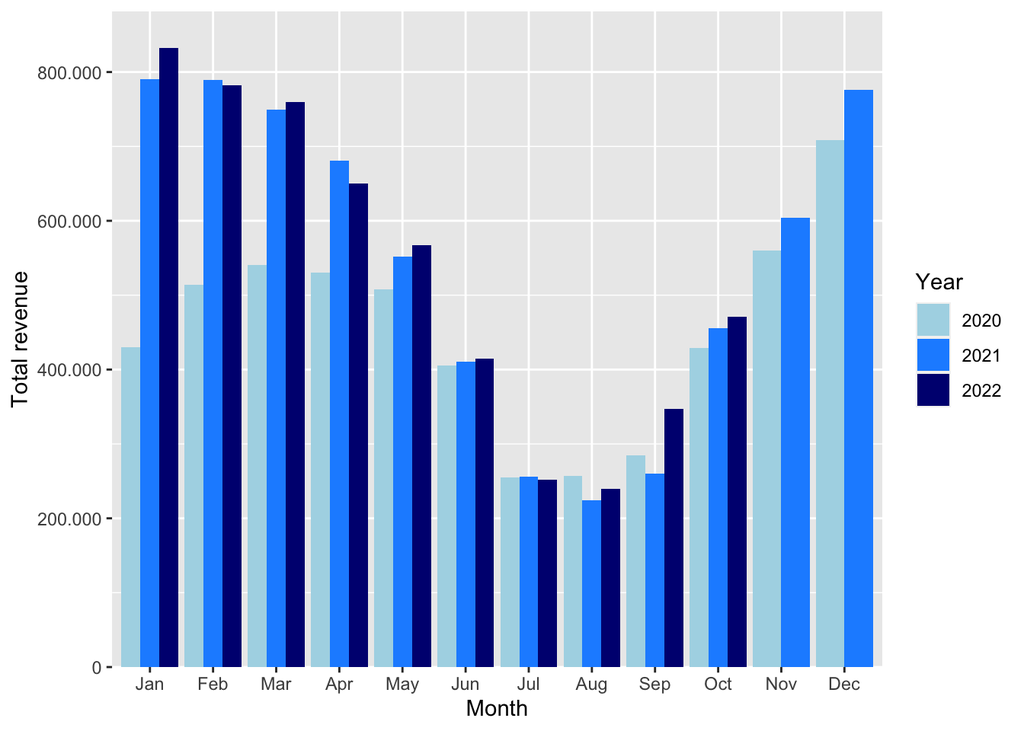

```r
library(scales)

ggplot(acme_revenue_total) +
      geom_bar(aes(x = factor(paste0(month), levels = paste0(1:12)),
                   y = total_revenue, group=year, fill = paste0(year)),
               stat = "identity",
               position = position_dodge()) +
  # customize the appeerance of the plot
  scale_fill_manual(values=c('lightblue', 'dodgerblue', 'navy')) +
  # extract the first three letters of the month names for x labels
  scale_x_discrete(labels = substr(month.name, 1, 3)) +
  scale_y_continuous(expand = expansion(add = c(0, 50000)), # add space above the data
                     labels = comma_format(big.mark = ".",
                                           decimal.mark = ",")) +
  labs(y = 'Total revenue', fill = 'Year', x = 'Month')
```

Print revenues for each month in a descending order.

```r
acme_revenue %>%
  mutate(m_y = format(date, '%B, %Y')) %>%
  group_by(m_y) %>%
  summarise(total_revenue = sum(revenue_dtc + revenue_amazon + revenue_walmart, na.rm = T)) %>%
  arrange(-total_revenue)
```

```
## # A tibble: 34 × 2
##    m_y            total_revenue
##    <chr>                  <dbl>
##  1 January, 2022      25111320.
##  2 January, 2021      23338171.
##  3 March, 2022        21870121.
##  4 February, 2021     21594627.
##  5 December, 2021     21414857.
##  6 February, 2022     21400773.
##  7 March, 2021        21098877.
##  8 December, 2020     19738946.
##  9 April, 2022        18555460.
## 10 April, 2021        17766589.
## # … with 24 more rows
```

**g. Does Acme’s marketing spend tend to follow a similar pattern to revenue?**

```r
library(anomalize)
```

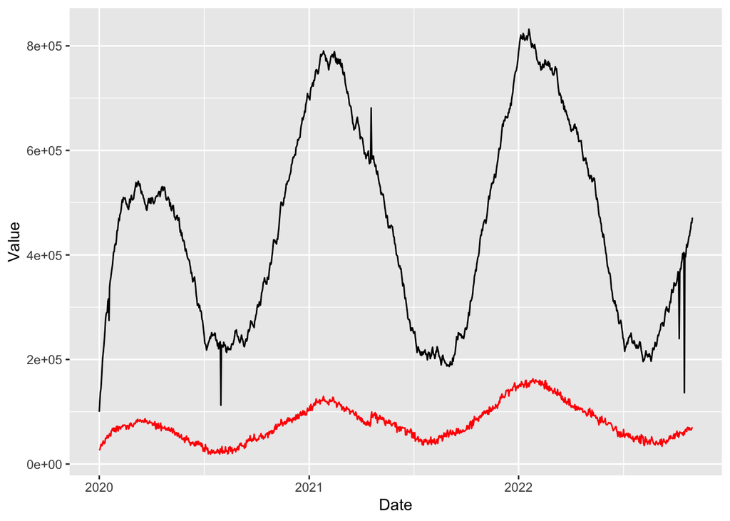

```r
acme_spend_total <- aggregate(acme_spend["spend"], by = acme_spend["date"],
                              FUN = sum, na.rm=TRUE, na.action=NULL)

merged <- acme_spend_total %>%
  full_join(., acme_revenue_total, by = 'date')

# plot total spend and revenue over time
merged %>% ggplot() +
  geom_line(aes(x = date, y = total_revenue)) +
  geom_line(aes(x = date, y = spend), color = "red") +
  labs(x = "Date", y = "Value")
```

```r
# create remainder datasets for revenue and spend
e_revenue <- acme_revenue_total %>% as_tibble() %>%
  time_decompose(total_revenue, method = "stl", frequency = "auto", trend = "auto") %>%
  anomalize(remainder, method = "gesd", alpha = 0.05, max_anoms = 0.2) %>% select(date, remainder)
```

```
## Converting from tbl_df to tbl_time.
## Auto-index message: index = date
```

```
## frequency = 7 days
```

```
## trend = 91 days
```

```r
e_spend <- acme_spend_total %>% as_tibble() %>%
  time_decompose(spend, method = "stl", frequency = "auto", trend = "auto") %>%
  anomalize(remainder, method = "gesd", alpha = 0.05, max_anoms = 0.2) %>% select(date, remainder)
```

```
## Converting from tbl_df to tbl_time.
## Auto-index message: index = date
```

```
## frequency = 7 days
```

```
## trend = 91 days
```

From the previous observations, it looks like the anomalies detected at the beginning of 2020 follow some previous trend from 2019 – get rid of these dates as the outliers for the 2020-2022 time period.

```r
# merge
e_merged <- e_revenue %>%
  filter(date > '2020-01-20') %>%
  full_join(e_spend, by = 'date',
            # add suffixes to differentiate the column names:
            suffix = c('.revenue', '.spend'))

merged <- merged %>% filter(date > '2020-01-20')
```

Fit linear regressions with year and month fixed effects and a set of lags for (1) the revenue and spend residual components of the time series data after the trend and seasonality have been removed and (2) original, non-decomposed data. This would allow to observe whether spend and revenue change concurrently.

```r
# stat. significant positive effect of spend on revenue for the decomposed data
summary(lm(remainder.revenue ~ remainder.spend, data = e_merged))
```

```
##
## Call:
## lm(formula = remainder.revenue ~ remainder.spend, data = e_merged)
##
## Residuals:
##     Min      1Q  Median      3Q     Max
## -261256  -12016     568   10872  100646
##
## Coefficients:
##                  Estimate Std. Error t value Pr(>|t|)
## (Intercept)     -213.3626   679.8472  -0.314    0.754
## remainder.spend    1.0663     0.1368   7.796 1.59e-14 ***
## ---
## Signif. codes:  0 '***' 0.001 '**' 0.01 '*' 0.05 '.' 0.1 ' ' 1
##
## Residual standard error: 21660 on 1013 degrees of freedom
##   (20 observations deleted due to missingness)
## Multiple R-squared:  0.0566, Adjusted R-squared:  0.05566
## F-statistic: 60.77 on 1 and 1013 DF,  p-value: 1.585e-14
```

```r
# include lags (also stat significance):
summary(lm(remainder.revenue ~ lag(remainder.spend, 1), data = e_merged))
```

```
##
## Call:
## lm(formula = remainder.revenue ~ lag(remainder.spend, 1), data = e_merged)
##
## Residuals:
##     Min      1Q  Median      3Q     Max
## -266558  -11592     167   11389  117792
##
## Coefficients:
##                          Estimate Std. Error t value Pr(>|t|)
## (Intercept)             -148.4797   682.1781  -0.218    0.828
## lag(remainder.spend, 1)    0.9605     0.1372   7.001 4.62e-12 ***
## ---
## Signif. codes:  0 '***' 0.001 '**' 0.01 '*' 0.05 '.' 0.1 ' ' 1
##
## Residual standard error: 21720 on 1012 degrees of freedom
##   (21 observations deleted due to missingness)
## Multiple R-squared:  0.0462, Adjusted R-squared:  0.04525
## F-statistic: 49.02 on 1 and 1012 DF,  p-value: 4.619e-12
```

```r
summary(lm(remainder.revenue ~ lag(remainder.spend, 7), data = e_merged))
```

```
##
## Call:
## lm(formula = remainder.revenue ~ lag(remainder.spend, 7), data = e_merged)
##
## Residuals:
##     Min      1Q  Median      3Q     Max
## -267825  -11712    -122   11461  113378
##
## Coefficients:
##                         Estimate Std. Error t value Pr(>|t|)
## (Intercept)              64.2596   685.8459   0.094    0.925
## lag(remainder.spend, 7)   0.8002     0.1376   5.817 8.07e-09 ***
## ---
## Signif. codes:  0 '***' 0.001 '**' 0.01 '*' 0.05 '.' 0.1 ' ' 1
##
## Residual standard error: 21770 on 1006 degrees of freedom
##   (27 observations deleted due to missingness)
## Multiple R-squared:  0.03254,    Adjusted R-squared:  0.03157
## F-statistic: 33.83 on 1 and 1006 DF,  p-value: 8.065e-09
```

```r
summary(lm(remainder.revenue ~ lag(remainder.spend, 1) +
             lag(remainder.spend, 7) + lag(remainder.spend, 30),
           data = e_merged %>%
             mutate(year = format(date, '%Y'))
           ))
```

```
##
## Call:
## lm(formula = remainder.revenue ~ lag(remainder.spend, 1) + lag(remainder.spend,
##     7) + lag(remainder.spend, 30), data = e_merged %>% mutate(year = format(date,
##     "%Y")))
##
## Residuals:
##     Min      1Q  Median      3Q     Max
## -262266  -11572    1028   11561  121147
##
## Coefficients:
##                           Estimate Std. Error t value Pr(>|t|)
## (Intercept)              -227.1588   670.3979  -0.339 0.734801
## lag(remainder.spend, 1)     0.8720     0.1415   6.162 1.05e-09 ***
## lag(remainder.spend, 7)     0.4979     0.1413   3.523 0.000446 ***
## lag(remainder.spend, 30)    0.8146     0.1338   6.089 1.63e-09 ***
## ---
## Signif. codes:  0 '***' 0.001 '**' 0.01 '*' 0.05 '.' 0.1 ' ' 1
##
## Residual standard error: 21040 on 981 degrees of freedom
##   (50 observations deleted due to missingness)
## Multiple R-squared:  0.09645,    Adjusted R-squared:  0.09368
## F-statistic:  34.9 on 3 and 981 DF,  p-value: < 2.2e-16
```

```r
# year effect
summary(lm(remainder.revenue ~  lag(remainder.spend, 1) +
             lag(remainder.spend, 7) + lag(remainder.spend, 30) + year,
           data = e_merged %>%
             mutate(year = format(date, '%Y'))
           ))
```

```
##
## Call:
## lm(formula = remainder.revenue ~ lag(remainder.spend, 1) + lag(remainder.spend,
##     7) + lag(remainder.spend, 30) + year, data = e_merged %>%
##     mutate(year = format(date, "%Y")))
##
## Residuals:
##     Min      1Q  Median      3Q     Max
## -263240  -11276    1093   11540  120322
##
## Coefficients:
##                            Estimate Std. Error t value Pr(>|t|)
## (Intercept)              -2075.3178  1183.7040  -1.753 0.079874 .
## lag(remainder.spend, 1)      0.8662     0.1414   6.124 1.32e-09 ***
## lag(remainder.spend, 7)      0.4956     0.1412   3.509 0.000469 ***
## lag(remainder.spend, 30)     0.8219     0.1340   6.132 1.26e-09 ***
## year2021                  2595.9601  1618.6633   1.604 0.109088
## year2022                  2868.5267  1689.1893   1.698 0.089794 .
## ---
## Signif. codes:  0 '***' 0.001 '**' 0.01 '*' 0.05 '.' 0.1 ' ' 1
##
## Residual standard error: 21020 on 979 degrees of freedom
##   (50 observations deleted due to missingness)
## Multiple R-squared:  0.09977,    Adjusted R-squared:  0.09517
## F-statistic:  21.7 on 5 and 979 DF,  p-value: < 2.2e-16
```

```r
# year + month effects
summary(lm(remainder.revenue ~ lag(remainder.spend, 1) +
             lag(remainder.spend, 7) + lag(remainder.spend, 30) + year + month,
           data = e_merged %>%
             mutate(year = format(date, '%Y'),
                    month = format(date, '%m'))
           ))
```

```
##
## Call:
## lm(formula = remainder.revenue ~ lag(remainder.spend, 1) + lag(remainder.spend,
##     7) + lag(remainder.spend, 30) + year + month, data = e_merged %>%
##     mutate(year = format(date, "%Y"), month = format(date, "%m")))
##
## Residuals:
##     Min      1Q  Median      3Q     Max
## -255178   -9245      92   10044  101911
##
## Coefficients:
##                            Estimate Std. Error t value Pr(>|t|)
## (Intercept)               3.596e+04  2.594e+03  13.859  < 2e-16 ***
## lag(remainder.spend, 1)   1.381e-01  1.236e-01   1.117   0.2644
## lag(remainder.spend, 7)  -5.542e-02  1.236e-01  -0.448   0.6541
## lag(remainder.spend, 30)  3.674e-01  1.231e-01   2.986   0.0029 **
## year2021                 -1.309e+03  1.353e+03  -0.968   0.3334
## year2022                  1.360e+02  1.447e+03   0.094   0.9251
## month02                  -2.649e+04  3.086e+03  -8.583  < 2e-16 ***
## month03                  -3.337e+04  2.877e+03 -11.598  < 2e-16 ***
## month04                  -2.812e+04  2.989e+03  -9.408  < 2e-16 ***
## month05                  -2.422e+04  2.908e+03  -8.330 2.75e-16 ***
## month06                  -4.611e+04  2.922e+03 -15.776  < 2e-16 ***
## month07                  -5.459e+04  3.066e+03 -17.804  < 2e-16 ***
## month08                  -4.421e+04  3.071e+03 -14.396  < 2e-16 ***
## month09                  -4.781e+04  3.025e+03 -15.805  < 2e-16 ***
## month10                  -4.535e+04  2.980e+03 -15.215  < 2e-16 ***
## month11                  -3.411e+04  3.288e+03 -10.375  < 2e-16 ***
## month12                  -2.735e+04  3.208e+03  -8.526  < 2e-16 ***
## ---
## Signif. codes:  0 '***' 0.001 '**' 0.01 '*' 0.05 '.' 0.1 ' ' 1
##
## Residual standard error: 17230 on 968 degrees of freedom
##   (50 observations deleted due to missingness)
## Multiple R-squared:  0.402,  Adjusted R-squared:  0.3921
## F-statistic: 40.67 on 16 and 968 DF,  p-value: < 2.2e-16
```

```r
# decomposed data
best_lag <- lapply(
  8:60,
  function(x) lm(remainder.revenue ~ lag(remainder.spend, 1) +
             lag(remainder.spend, 7) + lag(remainder.spend, x) + year + month,
           data = e_merged %>%
             mutate(year = format(date, '%Y'),
                    month = format(date, '%m'))
           )
)

# not decomposed
best_lag2 <- lapply(
  8:60,
  function(x) lm(total_revenue ~ lag(spend, 1) +
             lag(spend, 7) + lag(spend, x) + year + month,
           data = merged %>%
             mutate(year = format(date, '%Y'),
                    month = format(date, '%m'))
           )
)
```

Merge the lm residuals into a dataframe, and plot the estimated coefficients for the lags, visualizing 95% confidence intervals.

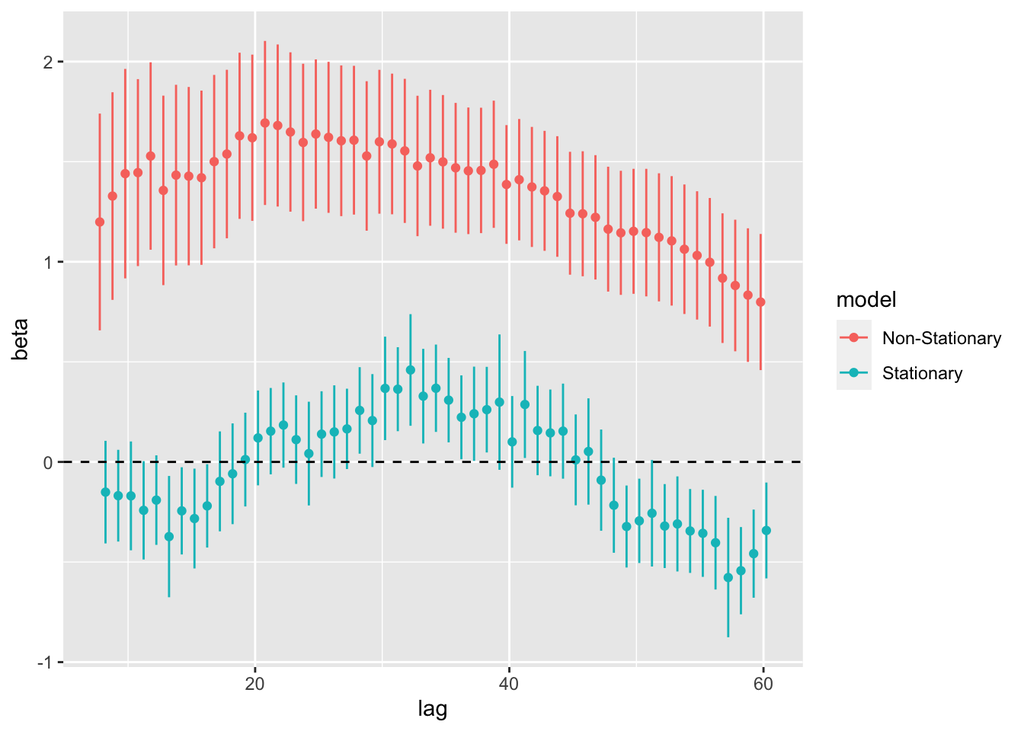

```r
library(sandwich)

rbind(
  data.frame(
  lag = 8:60,
  beta = sapply(best_lag, coef)[4,], # estimated coeffs for the lags
  se = unlist(lapply(best_lag, function(y) sqrt(diag(vcovHC(y, type = 'HC3')))[['lag(remainder.spend, x)']]
       )),
  model = 'Stationary'
),
data.frame(
  lag = 8:60,
  beta = sapply(best_lag2, coef)[4,],
  se = unlist(lapply(best_lag2, function(y) sqrt(diag(vcovHC(y, type = 'HC3')))[[4]]
       )),
  model = 'Non-Stationary'
)
) %>%
  ggplot() +
  geom_point(aes(x = lag, y = beta, color = model),
             position = position_dodge(width=0.9)) +
  geom_errorbar(aes(x = lag, ymin = beta - se*qnorm(0.975),
                    ymax = beta + se*qnorm(0.975), color = model), width = 0,
                position = position_dodge(width=0.9)) +
  geom_hline(yintercept = 0, linetype = 'dashed')
```